# Definiendo una derivada

Moises

17/3/2020

# Apuntes matematicas - Derivadas

Primero imaginemos que en un grafico tenemos una curva de una funcion cualquiera del 0 al 10,

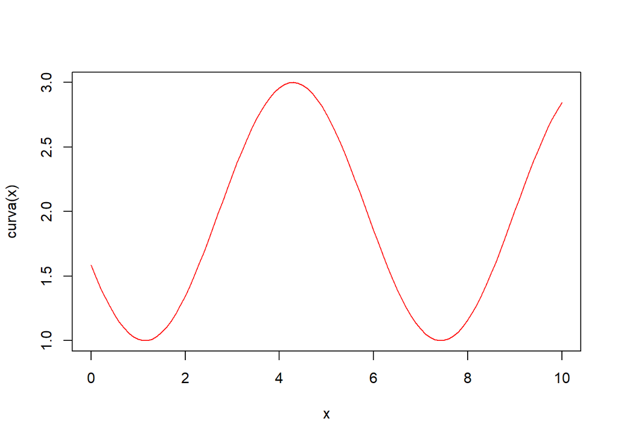

```r
curva = function(x){
  cos(x+2)+2
}

curve(curva(x), 0,10,col = "red")
```

A esa misma curva vamos a marcarle 2 puntos y unirlos por una recta

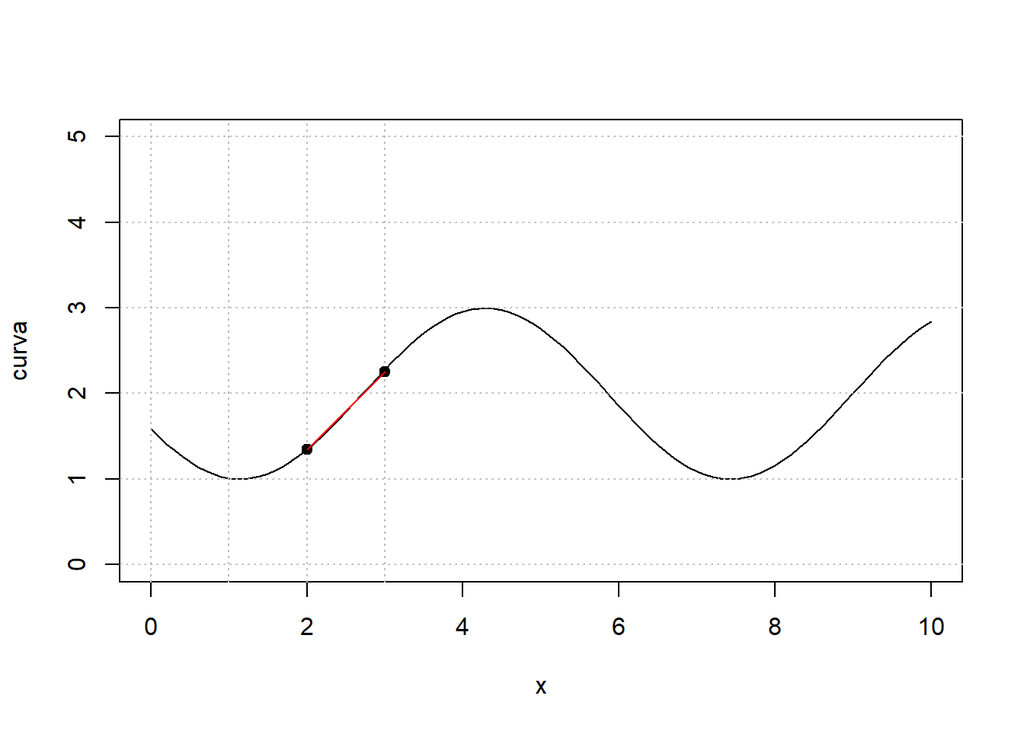

```r
plot(curva, xlim = c(0,10), ylim = c(0,5))
abline(h=0:9, v = -3:3, lty="dotted", col = "grey") #grid
points(2,1.35, pch = 19) #punto 1
points(3,2.25, pch = 19) #punto 2
lines(c(2,3), c(1.35,2.25), col = "red") #recta
```

Dicha recta es una recta secante a ambos puntos, porque la definicion de una recta secante es, una recta que une 2 o mas puntos

y la formula para encontrarla es:

(f(x+h) - f(x))/h

Donde h es el incremento de x, en este caso el incremento del primer punto(x) es 1 porque las coordenadas son (2,3) osea (x,x+h)

Veamoslo aqui

```r
secante = (curva(2+1) - curva(2))/1
secante
```

```
## [1] 0.9373058
```

La secante mide 0.9373058

Pero que tal si h fuera 0.00003. En ese caso obtendriamos una recta tocando practicamente en un solo punto (porque ambos estarian demasiado cerca).

En ese caso estariamos buscando la tangente o lo que es lo mismo que una recta que toca UN solo punto de la grafico

De ser asi, como entonces podemos obtener la tangente del primer punto?

Primero que nada, la definicion de una recta tangente es, una recta que toca UN solo punto de la grafico

En otras palabras

```r
derivada_o_tangente = (curva(2+0.00003) - curva(2))/0.00003
derivada_o_tangente
```

```
## [1] 0.7568123
```

La derivada de la funcion curve() en el punto (2,1,35) es 0.7568123